# Question

In a school, there are two clubs: club A and club B. Students can join one club, both clubs, or neither club.

- The number of students in neither club is 3.
- The number of students in only club A (and not club B) is 16.
- The number of students in both clubs (in A and B) is 23.
- The total number of students in the school is 48.

Calculate the following:

- How many students are in club A? ##ANSWER1## students
- How many students are in at least one club? ##ANSWER2## students
- How many students are only in club B (and not club A)? ##ANSWER3## students
- How many students are in club B? ##ANSWER4## students

## Answerlist

- 35
- 36
- 37
- 38
- 39
- 41
- 42
- 43
- 44
- 45
- 6
- 7
- 8
- 9
- 10
- 27
- 28
- 29
- 30
- 31

# Solution

- The number of students in club A is 39.
- The number of students in at least one club is 45.
- The number of students in only club B (and not club A) is 6.
- The number of students in club B is 29.

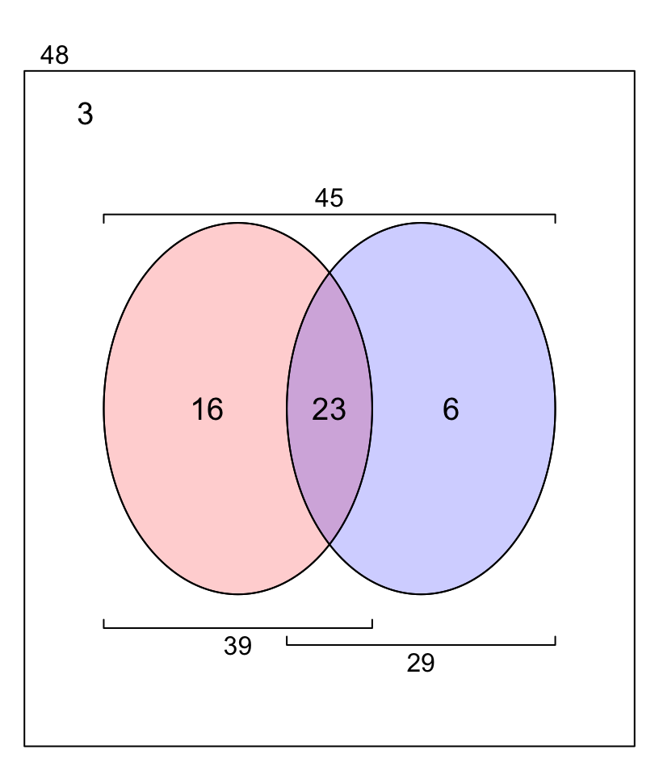

# Meta-information

extype: cloze exclozetype: schoice|schoice|schoice|schoice exsolution: 00001|00001|10000|00100 exname: venn_clubs